# Data Analysis with Python - Intro to Numpy slides

[figure not shown]

```python
from IPython.display import Image
Image("../src/photos/python_numpy.png")
```

### Introduction to Numpy

### First, Why?

```python
range(10)
```

```
range(0, 10)
```

```python
num_list = list(range(10))
num_list
```

```
[0, 1, 2, 3, 4, 5, 6, 7, 8, 9]
```

```python
num_list/3
```

```
---------------------------------------------------------------------------
TypeError                                 Traceback (most recent call last)
<ipython-input-4-db318cc73fb7> in <module>()
----> 1 num_list/3

TypeError: unsupported operand type(s) for /: 'list' and 'int'
```

### So What Makes Numpy So Amazing

```
help(np.array)
```

```python
import numpy as np
```

### Creating a Numpy Array

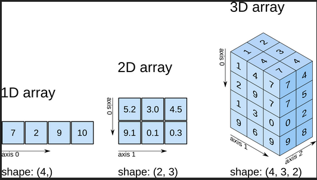

```python
Image("../src/photos/numpy_123D_array.png")
```

#### 1. Create an array from a regular Python list or tuple using the array function

```python
array_one = np.array([1,2,3,4])
array_one
```

```
array([1, 2, 3, 4])
```

```python
numbers = [9,8,7,6]
array_two = np.array(numbers)
array_two
```

```
array([9, 8, 7, 6])
```

#### 2. NumPy offers several functions to create arrays with initial placeholder content

Create an array of zeros with desired shape (x,y)

- x == number of rows
- y == number of columns in array

```python
array_of_zeroes = np.zeros((3,4))
array_of_zeroes
```

```
array([[0., 0., 0., 0.],
       [0., 0., 0., 0.],
       [0., 0., 0., 0.]])
```

```python
array_of_ones = np.ones((3,4))
array_of_ones
```

```
array([[1., 1., 1., 1.],
       [1., 1., 1., 1.],
       [1., 1., 1., 1.]])
```

#### np.empty() is not the same as np.zeros()

One may get the same output. But np.empty() returns a new array of given shape and type, without initializing entries (the entries may be zero but not always)  
Used when you plan to populate the array but need to create one quickly first. If you want an array of zeros, use np.zeros()

```python
array_empty = np.empty((2,3))
array_empty
```

```
array([[0., 0., 0.],
       [0., 0., 0.]])
```

#### np.eye() creates an eyedentity matrix

```python
array_eye = np.eye(3)
array_eye
```

```
array([[1., 0., 0.],
       [0., 1., 0.],
       [0., 0., 1.]])
```

[figure not shown]

```python
Image("../src/photos/alien_clean_litter.png")
```

#### 3. To create sequences of numbers, NumPy provides a function analogous to range that returns arrays instead of lists

arange(start, stop, step, dtype)

```python
array_of_evens = np.arange(2, 20, 2)
array_of_evens
```

```
array([ 2,  4,  6,  8, 10, 12, 14, 16, 18])
```

#### It also accepts float arguments

```python
array_of_floats = np.arange( 0, 2, 0.3)
array_of_floats
```

```
array([0. , 0.3, 0.6, 0.9, 1.2, 1.5, 1.8])
```

#### Two Dimensional Arrays

```python
array_2d = np.array([(2,4,6),(3,5,7)])
array_2d
```

```
array([[2, 4, 6],
       [3, 5, 7]])
```

```python
array_2d.shape
```

```
(2, 3)
```

#### Using reshape to create n dimensional arrays

```python
np.arange(6)
```

```
array([0, 1, 2, 3, 4, 5])
```

```python
array_nd = np.arange(6).reshape(3,2)
array_nd
```

```
array([[0, 1],
       [2, 3],
       [4, 5]])
```

The reshape will only take arguments that multiply to the number in arange function. For example: for arange(8), the possible combinations for reshape are (2,4), (4,2), (2,2,2)

```python
array_nd = np.arange(6).reshape(3,4)
array_nd
```

```
---------------------------------------------------------------------------
ValueError                                Traceback (most recent call last)
<ipython-input-17-02880c8c7a2c> in <module>()
----> 1 array_nd = np.arange(6).reshape(3,4)
      2 array_nd

ValueError: cannot reshape array of size 6 into shape (3,4)
```

If an array is too large to be printed, NumPy automatically skips the central part of the array and only prints the corners

```python
print(np.arange(10000))
```

```
[   0    1    2 ... 9997 9998 9999]
```

```python
print(np.arange(10000).reshape(100,100))
```

```
[[   0    1    2 ...   97   98   99]
 [ 100  101  102 ...  197  198  199]
 [ 200  201  202 ...  297  298  299]
 ...
 [9700 9701 9702 ... 9797 9798 9799]
 [9800 9801 9802 ... 9897 9898 9899]
 [9900 9901 9902 ... 9997 9998 9999]]
```

To disable this behaviour and force NumPy to print the entire array, you can change the printing options using set_printoptions.

```python
np.set_printoptions(threshold = np.nan)
```

```python
print(np.arange(10000).reshape(100,100))
```

[output not shown]

[output cut: 785 more lines]

```python
np.linspace(0,100,5)
```

[output not shown]

## Random Sample Generation

Generaring a uniform Distribution using `np.random()`

```python
np.random.rand(5)
```

```
array([0.52323177, 0.04750983, 0.78071173, 0.9961495 , 0.30023238])
```

```python
np.random.rand(5,5)
```

```
array([[0.27177236, 0.01288345, 0.84940704, 0.04916101, 0.53373383],
       [0.7852145 , 0.05941183, 0.06910575, 0.87665054, 0.71814835],
       [0.85645537, 0.64320912, 0.77700592, 0.5458375 , 0.60221291],
       [0.52707173, 0.55922759, 0.32750625, 0.31979445, 0.76499735],
       [0.78531228, 0.77965715, 0.33565106, 0.8500669 , 0.7895165 ]])
```

### Common Functions in Numpy

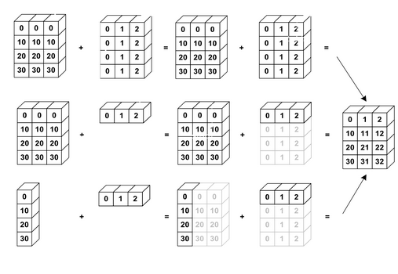

```python
Image("../src/photos/numpy_array_methods_arith.png")
```

## Arithmetic Operations

If the dimensions of two arrays are dissimilar, element-to-element operations are not possible. However, operations on arrays of non-similar shapes is still possible in NumPy, because of the broadcasting capability. We will see what broadcasting is in the upcoming lessons.

```python
a = np.array([10,10,10])
b = np.array([5,5,5])
```

```python
a + b
```

```
array([15, 15, 15])
```

```python
a / b
```

```
array([2., 2., 2.])
```

```python
a % 3
```

```
array([1, 1, 1])
```

```python
a < 35
```

```
array([ True,  True,  True])
```

```python
a ** 2
```

```
array([100, 100, 100])
```

[figure not shown]

```python
Image("../src/photos/keep_calm_ask.png")
```

## dot function or method

```python
A = np.array( [[1,1],[0,1]] )
B = np.array( [[2,0], [3,4]] )

print('A:\n', A)
print('B:\n', B)
```

```
A:
 [[1 1]
 [0 1]]
B:
 [[2 0]
 [3 4]]
```

#### This gives element-wise multiplication

```python
A * B
```

```
array([[2, 0],
       [0, 4]])
```

#### This gives the matrix multiplication

```python
A.dot(B)
```

```
array([[5, 4],
       [3, 4]])
```

```python
np.dot(A,B)
```

```
array([[5, 4],
       [3, 4]])
```

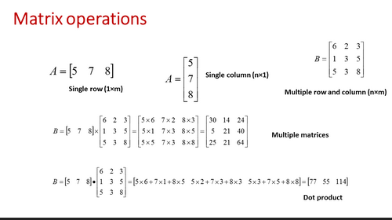

```python
Image("../src/photos/matrix_math.png")
```

## Modifying an existing array rather than create a new one

```python
a  *= 3
a
```

```
array([30, 30, 30])
```

```python
b += a
b
```

```
array([35, 35, 35])
```

### Built-In Methods

```python
ages = np.array([12,15,18,20])
```

```python
ages.sum()
```

```
65
```

```python
ages.min()
```

```
12
```

```python
ages.max()
```

```
20
```

[figure not shown]

```python
Image("../src/photos/haters_kitteh.png")
```

### Performing Math on Columns and Rows

By default, these operations apply to the array as though it were a list of numbers, regardless of its shape. However, by specifying the axis parameter you can apply an operation along the specified axis of an array

```python
numbers = np.arange(12).reshape(3,4)
numbers
```

```
array([[ 0,  1,  2,  3],
       [ 4,  5,  6,  7],
       [ 8,  9, 10, 11]])
```

#### Row and column operations

In a 2D array axis #0 represents columns. Axis #1 refers to rows

#### Sum up each column

```python
numbers.sum(axis=0)
```

```
array([12, 15, 18, 21])
```

#### Sum up each row

```python
numbers.sum(axis=1)
```

```
array([ 6, 22, 38])
```

#### Minimum of each row

```python
numbers.min(axis=1)
```

```
array([0, 4, 8])
```

[figure not shown]

```python
Image("../src/photos/nerd_kitteh.png")
```

### Statistical Functions

```python
test_scores = np.array([32.32, 56.98, 21.52, 44.32,
                        55.63, 13.75, 43.47, 43.34])
```

```python
print('Mean test scores of the students: ')
print(np.mean(test_scores))
```

```
Mean test scores of the students:
38.91625
```

```python
print('Median test scores of the students: ')
print(np.median(test_scores))
```

```
Median test scores of the students:
43.405
```

## Indexing and Slicing

This also follows zero based indexing like python lists

### 1D Arrays

One-dimensional arrays can be indexed, sliced and iterated over, much like lists and other Python sequences. The **(start:stop:step)** notation for slicing is used

```python
a = np.arange(11)**2
```

```python
a
```

```
array([  0,   1,   4,   9,  16,  25,  36,  49,  64,  81, 100])
```

```python
a[-2]
```

```
81
```

```python
a[2:7]
```

```
array([ 4,  9, 16, 25, 36])
```

```python
a[2:-2]
```

```
array([ 4,  9, 16, 25, 36, 49, 64])
```

```python
a[2:]
```

```
array([  4,   9,  16,  25,  36,  49,  64,  81, 100])
```

```python
a[:11:2]
```

```
array([  0,   4,  16,  36,  64, 100])
```

```python
a[::-1]
```

```
array([100,  81,  64,  49,  36,  25,  16,   9,   4,   1,   0])
```

### 2D Arrays

Consider an array students, it contains the test scores in two courses of the students against their names

```python
students = np.array([['Alice','Beth','Cathy','Dorothy'],
                     [65,78,90,81],
                     [71,82,79,92]])
```

```python
students
```

```
array([['Alice', 'Beth', 'Cathy', 'Dorothy'],
       ['65', '78', '90', '81'],
       ['71', '82', '79', '92']], dtype='<U7')
```

```python
students[2]
```

```
array(['71', '82', '79', '92'], dtype='<U7')
```

```python
students[0,1]
```

```
'Beth'
```

#### 2D Array slicing

This will consider the rows 0 and 1, columns 2 and 3

```python
students[0:2,2:4]
```

```
array([['Cathy', 'Dorothy'],
       ['90', '81']], dtype='<U7')
```

##### All rows and column 1

```python
students[:,1:2]
```

```
array([['Beth'],
       ['78'],
       ['82']], dtype='<U7')
```

##### All rows, columns 1 and 2

```python
students[:,1:3]
```

```
array([['Beth', 'Cathy'],
       ['78', '90'],
       ['82', '79']], dtype='<U7')
```

##### All columns, rows 0 and 1

```python
students[0:2,:]
```

```
array([['Alice', 'Beth', 'Cathy', 'Dorothy'],
       ['65', '78', '90', '81']], dtype='<U7')
```

##### All rows and columns

```python
students[:]
```

```
array([['Alice', 'Beth', 'Cathy', 'Dorothy'],
       ['65', '78', '90', '81'],
       ['71', '82', '79', '92']], dtype='<U7')
```

##### The last row

```python
students[-1,:]
```

```
array(['71', '82', '79', '92'], dtype='<U7')
```

##### 3rd from last to second from last row, last two columns

```python
students[-3:-1,-2:]
```

```
array([['Cathy', 'Dorothy'],
       ['90', '81']], dtype='<U7')
```

### dots or ellipsis(...)

Slicing can also include ellipsis (…) to make a selection tuple of the same length as the dimension of an array. The dots (...) represent as many colons as needed to produce a complete indexing tuple

Select row 0 and all columns

```python
students[0,...]
```

```
array(['Alice', 'Beth', 'Cathy', 'Dorothy'], dtype='<U7')
```

### Filtering an Array

```python
a = np.arange(16).reshape(4,4)
```

```python
a
```

```
array([[ 0,  1,  2,  3],
       [ 4,  5,  6,  7],
       [ 8,  9, 10, 11],
       [12, 13, 14, 15]])
```

Now we find the elements that are greater than 9. This will return a numpy array of the same shape as our original array.

```python
indx_bool = a > 9
```

```python
indx_bool
```

```
array([[False, False, False, False],
       [False, False, False, False],
       [False, False,  True,  True],
       [ True,  True,  True,  True]])
```

We use this array to select elements in a corresponding to 'true' values in the boolean array.

```python
a[indx_boo]
```

[output not shown]

We can do all of the above in a single concise statement

```python
print(a[a > 9])
```

```
[10 11 12 13 14 15]
```

### Counting

#### How many values less than 6?

```python
a < 6
```

```
array([[ True,  True,  True,  True],
       [ True,  True, False, False],
       [False, False, False, False],
       [False, False, False, False]])
```

```python
np.count_nonzero(a < 6)
```

```
6
```

```python
np.sum(a < 6)
```

```
6
```

#### How many values less than 6 in each row?

```python
np.sum(a < 6, axis=1)
```

```
array([4, 2, 0, 0])
```

#### Are there any values greater than 8?

```python
np.any(a > 8)
```

```
True
```

#### Are all values less than 10?

```python
np.all(a < 10)
```

```
False
```

#### Are all values less than 100?

```python
np.all(a < 100)
```

```
True
```

#### Are all values in each row less than 9?

```python
np.all(a < 9, axis=1)
```

```
array([ True,  True, False, False])
```

[figure not shown]

```python
Image("../src/photos/pre_pew_kitteh.png")
```